# RDA_Genomic_Offset

Thomas Francisco

2024-05-13

```r
meta_data_pop <- read.csv("C:/Users/tfrancisco/Documents/Thèse/Data/Espèces/Taxus_baccata/Populations/taxus_sample_29pop.csv",h=T,sep=";",dec=",")
```

This script is calculating the genomic offset index using the RDA method. Genomic offset is a metric first proposed by Fitzpatrick and Keller in 2015. The goal is to calculate how much the genomic composition of populations/ individuals will need to change in the future to maintain their fitness in the context of climate change. In other word, the genomic offset is the distance between the past/present and future genomic composition of potentially adaptive SNPs to climate. To calculate genomic offset, we need to identified potentially adaptive SNPs (or the all set of SNPs depending on the assumption underlying local adaptation) to climate and then estimate the past/present and future genomic composition of these SNPs. (To identified potentially outliers see previous scripts on candidates and outliers identification). To estimate the genomic composition, we will use genotype environmental association (GEAs) methods on the identified outliers (or all the SNPs). The GEAs methods will identified relationship between the allelic variation and climatic variables. Then, based on these association and knowing the past/present and future climatic data, we can estimate the allelic composition of all location knowing the climatic data -> we can interpolate/extrapolate the GEa relation into space and time. This will estimate the genomic composition and then we can performed an euclidean distance to calculate the genomic offset. To summaries, in order to calculate genomic offset, we need:  
- past/present and future climatic data  
- genomic data  
- optional: outliers  
- calculate GEA relationship between genomic data (or outliers) and past/present - interpolate/extrapolate the GEA relationship to space and time  
- calculate euclidean distance between the past/present and future genomic composition

```
    1. Past/present and future climatic data
```

The data have been extracted and processed in the script: New_processing_climatic_data_april (changer le nom des scripts).

```r
#climatic/structure/IBD data
load("C:/Users/tfrancisco/Documents/Thèse/Data/Espèces/Taxus_baccata/GEA_new_var/variance_partitioning/Climatic_data_RDA_pRDA.Rdata")
```

Here we will also load the raster data not scaled but with the mean and sd values of the past climatic data to scaled the data together to follow Capblancq et al. 2021 using their functions.

```r
#load past and future raster data
climatic_variables_to_keep <-c("bio1", "bio12", "bio15","bio2","bio4","bio9") #subset of retained clim var, see script processing clim data
list_raster <- c("past_climatic_data_raster","future_climatic_data_raster")

for(x in 1:length(list_raster)){
  name <- c("past","future")
  name_clim <- name[x]#name final raster
  var <- list_raster[x]#name of the raster
  load(paste0("C:/Users/tfrancisco/Documents/Thèse/Data/Espèces/Taxus_baccata/Genomic_offset/RDA/",var,".Rdata")) #load data
  raster_clim <- get(var)[[climatic_variables_to_keep]]#keep only var in clim_variables to keep
  names(raster_clim)=c("Annual_Tc","Annual_P","P_Seasonality","Diurnal_range_Tc","Tc_Seasonality","Tc_driest_quarter") #change the name to match the names of the scaled and center values

  assign(paste0("raster_",name_clim,"_clim"),raster_clim)
}
```

We also need to load the scale and center values:

```r
load("C:/Users/tfrancisco/Documents/Thèse/Data/Espèces/Taxus_baccata/Climatic_data/new_selection/scale_env_value_new_cli.Rdata")
load("C:/Users/tfrancisco/Documents/Thèse/Data/Espèces/Taxus_baccata/Climatic_data/new_selection/center_env_value_new_cli.Rdata")
```

The data here are the raster with the global extent, we need to load a shapefile containing the coordinates of the area of interest (here only the 29 pop of Taxus baccata):

```r
#range_pop <- readOGR("C:/Users/tfrancisco/Documents/Stage M2/genetic_data_with_nex_indiv/theshapefilegood.shp")

range_pop <- readOGR("C:/Users/tfrancisco/Documents/Thèse/Data/Espèces/Taxus_baccata/Genomic_offset/RDA/bis.shp")
```

We also need to check if the rasters have Nas:

```r
#?limination des NA et choix nom variables
remove.NAs.stack<-function(rast.stack){
  nom<-names(rast.stack)
  test1<-calc(rast.stack, fun=sum)
  test1[!is.na(test1)]<-1
  test2<-rast.stack*test1
  test2<-stack(test2)
  names(test2)<-nom
  return(test2)
}

#raster_past_clim_no_Na <- remove.NAs.stack(raster_past_clim)
```

There is no Nas, we will not perform this function every time because it take some times to run.

```
    2. Genomic data
```

The genomic data is the dataset with correction for MAC in allelic frequency for the 29 pop:

```r
#genomic data
load("C:/Users/tfrancisco/Documents/Thèse/Data/Espèces/Taxus_baccata/genetic_new/data_allelic_frequencies_29pop_adapcon_gentree_475_8616.Rdata")

genomic_matrix <- data_allelic_frequencies_29pop_adapcon_gentree_475_8616
```

```
  3. Outliers data
```

We created 2 set of outliers:

```
- One with less conservatives thresholds
```

```r
#set of less conservative thresholds
load("C:/Users/tfrancisco/Documents/Thèse/Results/species/taxus/GEA_new_var/outliers/outliers_set_final_overlapping_no_LD_LC_new_var.Rdata")
```

- One with more conservatives thresholds

```r
load("C:/Users/tfrancisco/Documents/Thèse/Results/species/taxus/GEA_new_var/outliers/outliers_set_final_overlapping_no_LD_new_var.Rdata")
```

```
  4. Calculate GEA relationship
```

We will based our GEA analysis on the relation between the outliers and the climatic variables. In this script, we will use the Redundancy analysis (RDA). First, we need to perform the GEA analysis on the outliers to identified the relationship that will then be interpolate/extrapolate. To do that, we performed the RDA on the outliers and the retained climatic variables same as before when we performed the candidate detection using RDA:

- LC outliers set

```r
RDA_outliers <- rda(formula = genomic_matrix[outliers_set_final_overlapping_no_LD_LC_new_var] ~  Annual_Tc+Diurnal_range_Tc+Tc_Seasonality+Tc_driest_quarter+Annual_P+P_Seasonality, data = Climatic_data_RDA_pRDA, scale=F)

RsquareAdj(RDA_outliers)
```

```
## $r.squared
## [1] 0.5181928
##
## $adj.r.squared
## [1] 0.3867909
```

- COnservative outliers set

```r
RDA_outliers_MC <- rda(formula = genomic_matrix[outliers_set_final_overlapping_no_LD_new_var] ~  Annual_Tc+Diurnal_range_Tc+Tc_Seasonality+Tc_driest_quarter+Annual_P+P_Seasonality, data = Climatic_data_RDA_pRDA, scale=F)

RsquareAdj(RDA_outliers_MC)
```

```
## $r.squared
## [1] 0.5947706
##
## $adj.r.squared
## [1] 0.4842534
```

For further analysis, we will perform the analysis on the different outliers sets to see if we find the same patterns depending on the thresholds:

```r
list_outliers_set <- c("outliers_set_final_overlapping_no_LD_LC_new_var","outliers_set_final_overlapping_no_LD_new_var")
list_RDA <- c("RDA_outliers","RDA_outliers_MC")
```

We can plot as before to see the repartition of outliers along the RDA axis and the climatic variables:

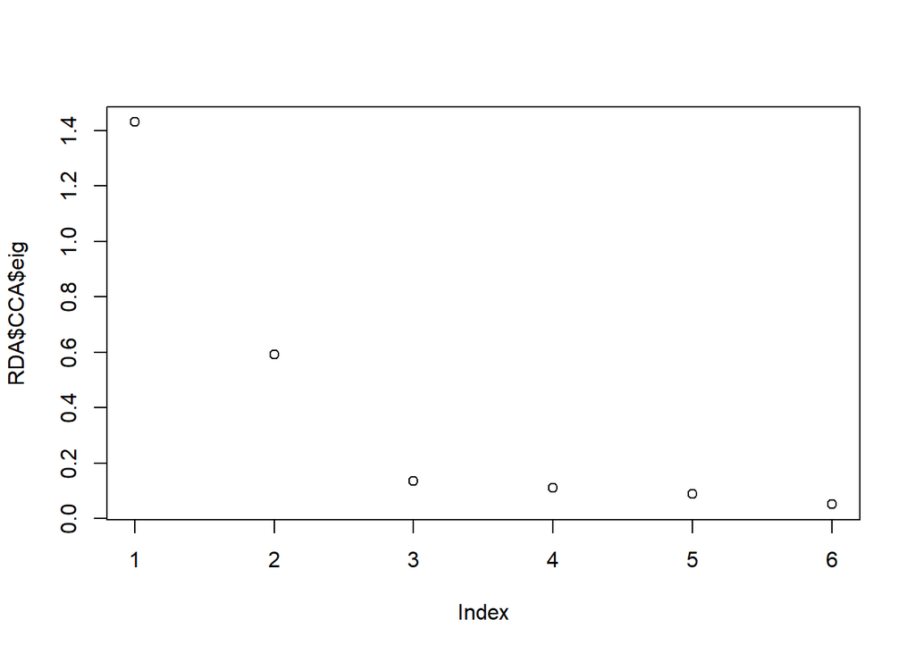

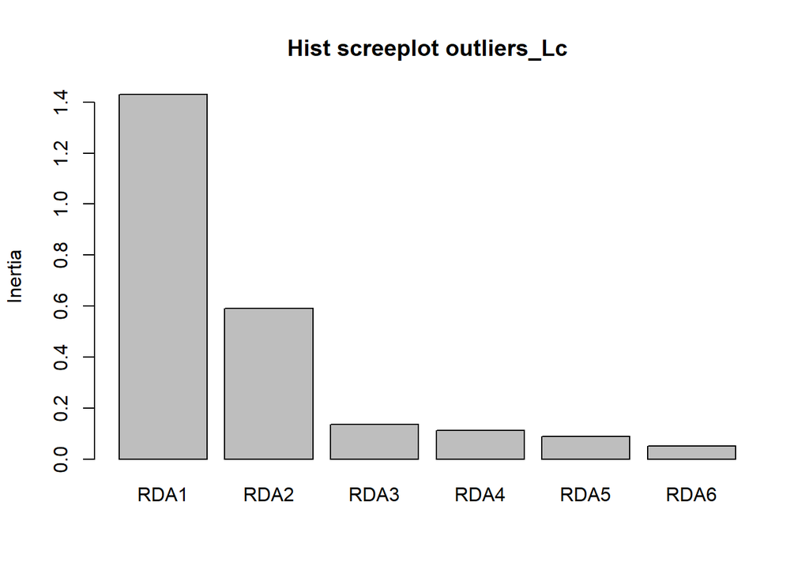

```
##      RDA1      RDA2      RDA3      RDA4      RDA5      RDA6
## 59.377320 24.556750  5.628020  4.639736  3.658607  2.139567
```

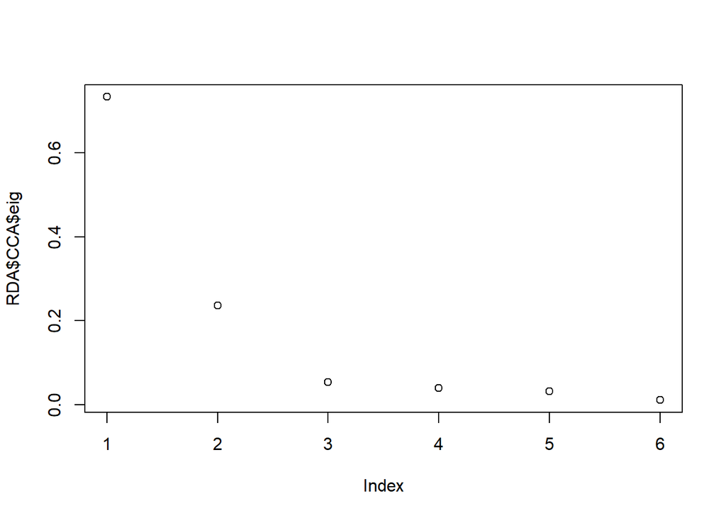

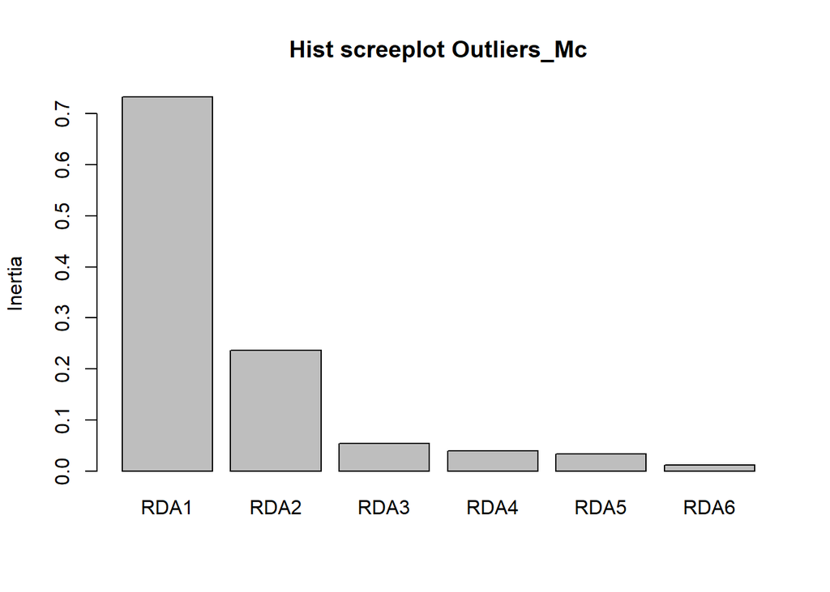

```
##      RDA1      RDA2      RDA3      RDA4      RDA5      RDA6
## 66.157255 21.346013  4.878507  3.599513  2.974937  1.043774
```

```r
for(x in 1: length(list_RDA)){
  RDA <- get(list_RDA[x])
  name <- c("outliers_Lc","Outliers_Mc")
  #screeplot
plot(RDA$CCA$eig, option="screeplot")

#in hist
screeplot_RDA <- screeplot(RDA,main = paste0("Hist screeplot ",name[x]))

#explained variance along each RDA axis
explain_variance <-RDA$CCA$eig*100/sum(RDA$CCA$eig)

assign(paste0("explain_variance",name[x]),explain_variance)

  print(get(paste0("explain_variance",name[x])))

}
```

We can see that the 2 first RDA axis seems to explain the major part of the genetic variation of the outliers for both set. We will use the 2 axis for further analysis for each sets.

We can plot the loci and the climatic variables in the RDA space to visualize:

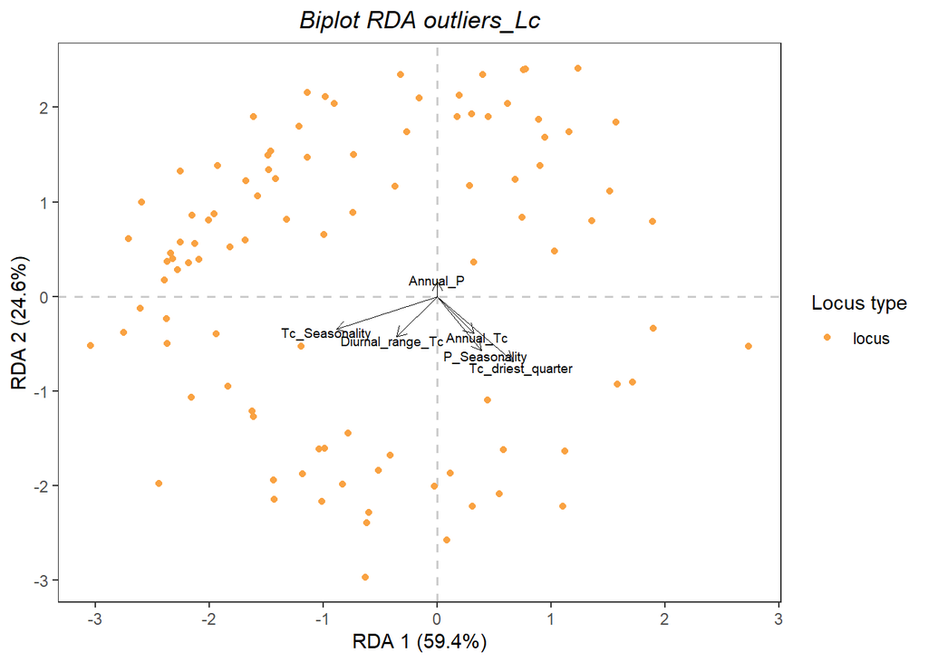

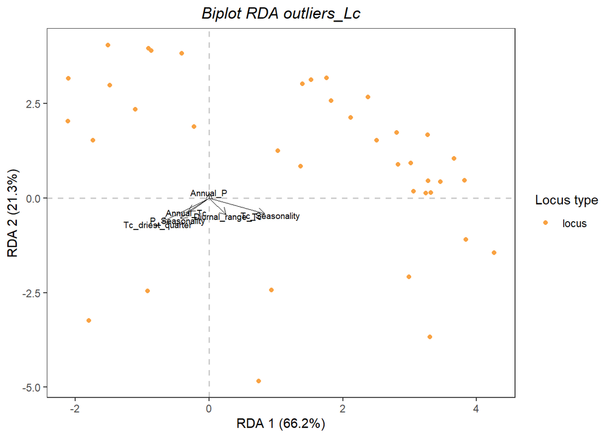

```r
for(x in 1:length(list_RDA)){

  RDA <- get(list_RDA[x])
  name <- c("outliers_Lc","Outliers_Mc")

  score_loci <- as.data.frame(scores(RDA, choices=c(1:2), display="species", scaling="none"))
score_climatic_var <- as.data.frame(scores(RDA, choices=c(1:2), display="bp"))
explained_variance_round <- round(RDA$CCA$eig*100/sum(RDA$CCA$eig),digits=1)

#Biplot with SNPs and climatic variables along the two first RDA axis.
 biplot_outliers_RDA<- ggplot() +
  geom_hline(yintercept=0, linetype="dashed", color = gray(.80), size=0.6) +
  geom_vline(xintercept=0, linetype="dashed", color = gray(.80), size=0.6) +
  geom_point(data = score_loci, aes(x=RDA1*15, y=RDA2*15,color="locus"), size = 1.4) +
  geom_segment(data = score_climatic_var, aes(xend=RDA1, yend=RDA2, x=0, y=0), colour="black", size=0.15, linetype=1, arrow=arrow(length = unit(0.02, "npc"))) +
  geom_text(data = score_climatic_var, aes(x=1.1*RDA1, y=1.1*RDA2, label = row.names(score_climatic_var)), size = 2.5) +
  xlab(paste0("RDA 1 (",explained_variance_round[1],"%)")) +
  ylab(paste0("RDA 2 (",explained_variance_round[2],"%)")) +
   ggtitle(paste0("Biplot RDA ",name)) +
  guides(color=guide_legend(title="Locus type")) +
  scale_color_manual(values ="#F9A242FF") +
  theme_bw(base_size = 11) +
  theme(legend.position="right", panel.grid = element_blank(), strip.text = element_text(size=11),plot.title = element_text(hjust = 0.5,color = "Black",face="italic"))

 print(biplot_outliers_RDA)

 #save plots

 pdf(paste0("C:/Users/tfrancisco/Documents/Thèse/Results/species/taxus/Genomic_offset/RDA/figures/biplot_outliers_RDA_",name[x],".pdf"));print(biplot_outliers_RDA);dev.off()
}
```

We can see that there is a pattern of continentality/Elevation along the first axis with more colder temperature, more seasonality of temperature and diurnal range of temperature on the left part associated to continental or high altitude. On the right, we seems to have outliers associated to more important temperature and more importantly during the driest quarter of the year, more precipitation seasonality. These pattern are associated to less continental or lower altitude. We can also plot the population in this space to see the repartition of populations are following what we see.

For the MC set, we can see that the pattern is the same but reverse for RDA first axis.

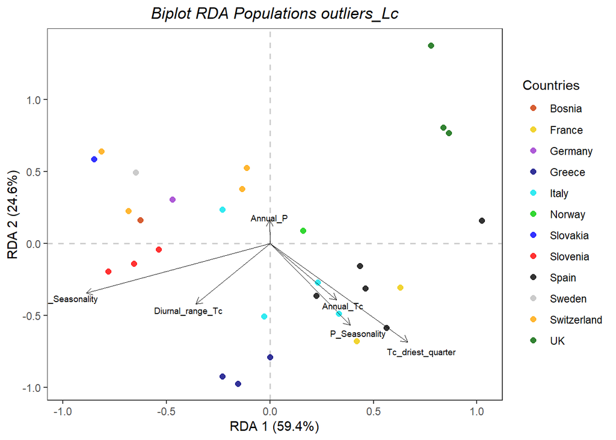

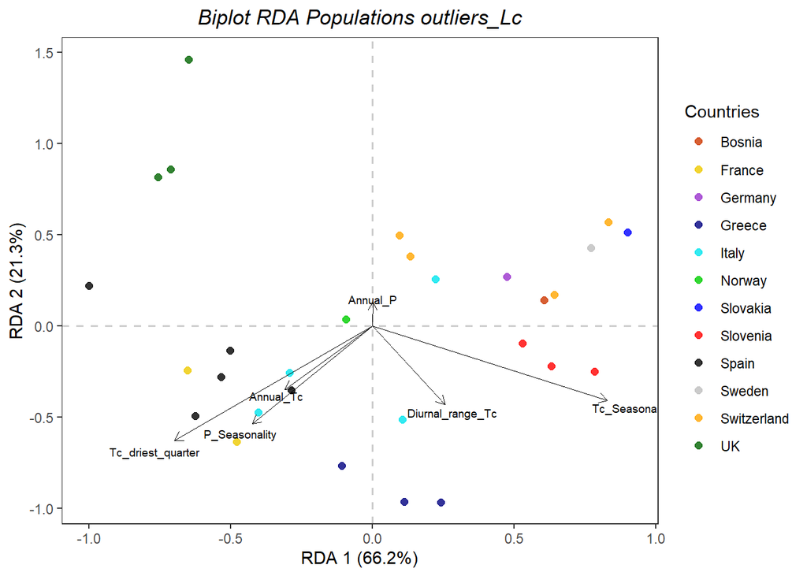

```r
for(x in 1:length(list_RDA)){
  RDA <- get(list_RDA[x])
  name <- c("outliers_Lc","Outliers_Mc")

  #score along the 2 first RDA axis
score_climatic_var <- as.data.frame(scores(RDA, choices=c(1:2), display="bp"))
Score_population <- data.frame(RDA$CCA$u[,c(1,2)])

#explained variance
explained_variance_round <- round(RDA$CCA$eig*100/sum(RDA$CCA$eig),digits=1)

#merge for country info
Score_population_bis <- rownames_to_column(Score_population,"Population")
score_with_country_info <- merge(Score_population_bis,meta_data_pop[,c(1,2)],"Population")
score_with_country_info$Country <- as.factor(score_with_country_info$Country)


group_palette <- c("Bosnia"="orangered3", "France"="gold2","Germany"= "darkorchid3", "Greece"="navyblue", "Italy"="turquoise2", "Norway"="green3", "Slovakia"="blue", "Slovenia"="red", "Spain"="black", "Sweden"="gray", "Switzerland"="orange", "UK"="darkgreen")


##Biplot with populations and climatic variables along the 2 first RDA axis
biplot_populations <- ggplot() +
  geom_hline(yintercept = 0, linetype = "dashed", color = gray(0.80), size = 0.6) +
  geom_vline(xintercept = 0, linetype = "dashed", color = gray(0.80), size = 0.6) +
  geom_point(data = score_with_country_info, aes(x = RDA1 * 3, y = RDA2 * 3, colour = Country), size = 2, alpha = 0.8) +
  geom_segment(data = score_climatic_var, aes(xend = RDA1, yend = RDA2, x = 0, y = 0), colour = "black", size = 0.15, linetype = 1, arrow = arrow(length = unit(0.02, "npc"))) +
  geom_text(data = score_climatic_var, aes(x=1.1*RDA1, y=1.1*RDA2, label = row.names(score_climatic_var)), size = 2.5)+
  xlab(paste0("RDA 1 (",explained_variance_round[1],"%)")) +
  ylab(paste0("RDA 2 (",explained_variance_round[2],"%)")) +
  ggtitle(paste0("Biplot RDA Populations ",name)) +
  scale_color_manual(name = "Countries", values = group_palette, labels = levels(score_with_country_info$Country)) +
  theme_bw(base_size = 11) +
  theme(legend.position="right", panel.grid = element_blank(), strip.text = element_text(size=11),plot.title = element_text(hjust = 0.5,color = "Black",face="italic"))+
  labs(color = "Country")

 print(biplot_populations)

#save plots

 pdf(paste0("C:/Users/tfrancisco/Documents/Thèse/Results/species/taxus/Genomic_offset/RDA/figures/biplot_population_RDA_",name[x],".pdf"));print(biplot_populations);dev.off()

}
```

We can see for the that the pattern we saw previously with the snps are in accordance here. Indeed, more continental or higher in altitude populations are on the left and the opposite pattern of population on the left. Same as before, for the MC outliers set, the pattern along RDA first axis is reverse but the information stayed the same.

```
    5. Interpolate/extrapolate the GEA relationship to space and time
```

The next step is to perform the interpolation/ extrapolation of the GEA relationship into time to estimate the past and future genomic composition for the outliers identified for the 29 populations. To do this, we will follow Capblancq et al in 2021 to calculate an adaptive index per RDA axis that is the scaled cliamtic values * the loading score of the variable along the consider RDA axis.

```r
adaptive_index_function <- function(RDA, K, env_pres,coords, scale_env, center_env){

  # Formatting environmental rasters for projection
  var_env_proj_pres <- raster::extract(env_pres, coords)
    var_env_proj_RDA <- data.frame(var_env_proj_pres[,c(1,4,5,6,2,3)])#put it in the same order as center_env and scale object
  # Standardization of the environmental variables
  var_env_proj_RDA_scale <- as.data.frame(scale(var_env_proj_RDA, center_env[row.names(RDA$CCA$biplot)], scale_env[row.names(RDA$CCA$biplot)]))


  # Predicting pixels genetic component based on RDA axes
  Proj_pres <- list()
    for(i in 1:K){
      ras_pres <- data.frame(coords, value = as.vector(apply(var_env_proj_RDA_scale[,names(RDA$CCA$biplot[,i])], 1, function(x) sum( x * RDA$CCA$biplot[,i]))))
      names(ras_pres) <- c("Longitude","Latitude",paste0("RDA_pres_", as.character(i)))
      Proj_pres[[i]] <- ras_pres
      names(Proj_pres)[i] <- paste0("RDA", as.character(i))
    }
    # Returning projections for current climates for each RDA axis
  return(Proj_pres = Proj_pres)
  }
```

We can apply this function to our dataset for the past and future climatic data:

```
 - Past adaptive index
```

- LC set

```r
coords<- data.frame(apply(meta_data_pop[,c(5:4)], 2, as.numeric))#we need to have longitude then latitude

#past adaptive index
past_adaptive_index <- adaptive_index_function(RDA_outliers,2,raster_past_clim,coords,scale_env_value_new_cli,center_env_value_new_cli)

past_score_RDA <- list(past_adaptive_index$RDA1, past_adaptive_index$RDA2)
merge_RDA_past_score <- as.data.frame(past_score_RDA[1:2])
df_RDA_past_score <- merge_RDA_past_score[,-c(4,5)]
```

- MC set

```r
coords<- data.frame(apply(meta_data_pop[,c(5:4)], 2, as.numeric))#we need to have longitude then latitude

#past adaptive index
past_adaptive_index_MC <- adaptive_index_function(RDA_outliers_MC,2,raster_past_clim,coords,scale_env_value_new_cli,center_env_value_new_cli)

past_score_RDA_MC <- list(past_adaptive_index_MC$RDA1, past_adaptive_index_MC$RDA2)
merge_RDA_past_score_MC <- as.data.frame(past_score_RDA_MC[1:2])
df_RDA_past_score_MC <- merge_RDA_past_score_MC[,-c(4,5)]
```

```
- Future adaptive index:
```

- LC set

```r
#future adaptive index
future_adaptive_index <- adaptive_index_function(RDA_outliers,2,raster_future_clim,coords,scale_env_value_new_cli,center_env_value_new_cli)

future_score_RDA <- list(future_adaptive_index$RDA1, future_adaptive_index$RDA2)
merge_RDA_future_score <- as.data.frame(future_score_RDA[1:2])

df_RDA_future_score <- merge_RDA_future_score[,-c(4,5)]
```

- MC set

```r
#future adaptive index
future_adaptive_index_MC <- adaptive_index_function(RDA_outliers_MC,2,raster_future_clim,coords,scale_env_value_new_cli,center_env_value_new_cli)

future_score_RDA_MC <- list(future_adaptive_index_MC$RDA1, future_adaptive_index_MC$RDA2)
merge_RDA_future_score_MC <- as.data.frame(future_score_RDA_MC[1:2])

df_RDA_future_score_MC <- merge_RDA_future_score_MC[,-c(4,5)]
```

We can plot the past and future adaptive values across the populations:

First, we need to scale the values for RDA1 and RDA2 for visual representation otherwise, the color will not mean the same things between past and future. During this step, we need to scale the past and future values together for each RDA axis to have the same scale across periods.

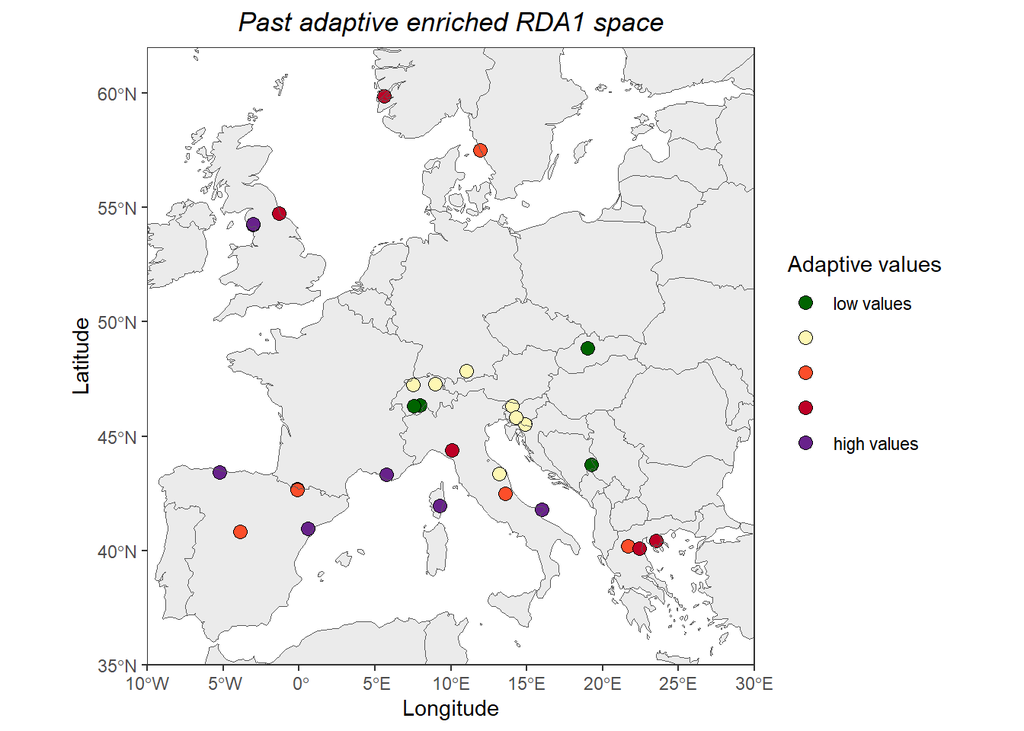

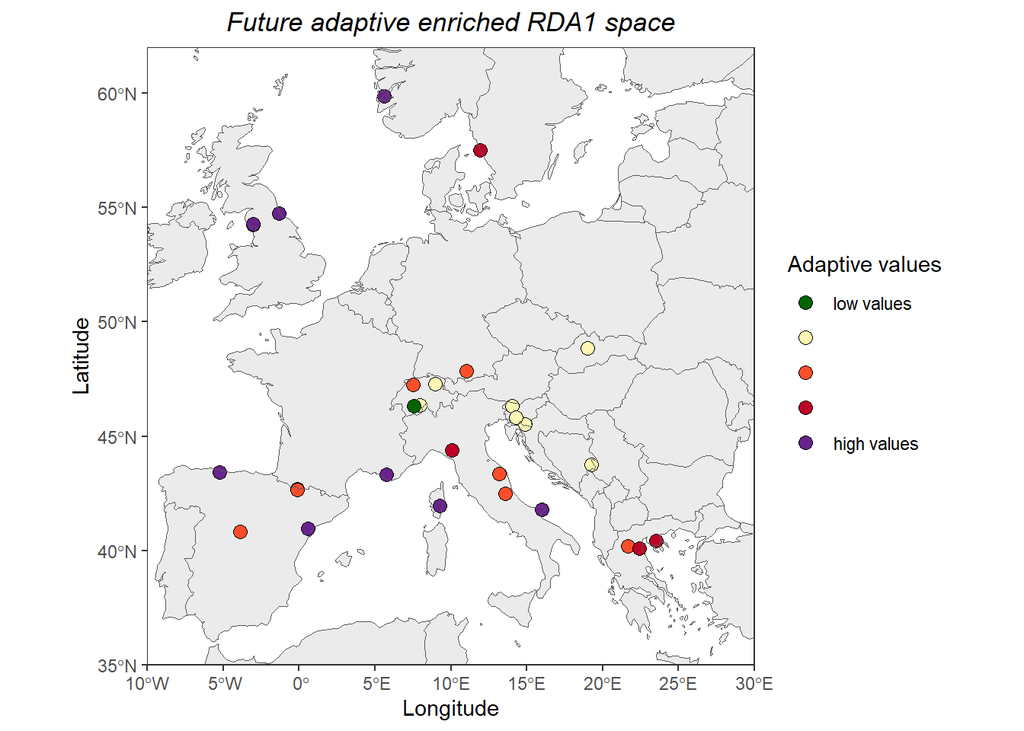

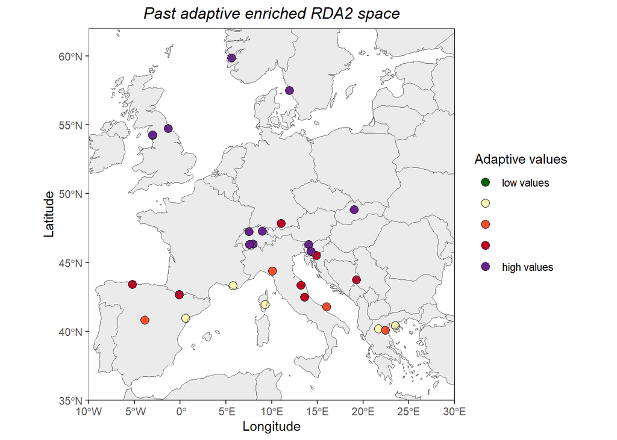

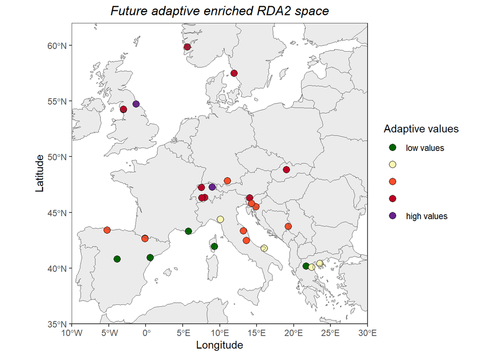

```
6. Genomic offset: calculation euclidean distance between the past/present and future genomic composition
```

```r
#number of retained axis
K=2
  name_list <- c("RDA1","RDA2")
for(x in 1:K){

  names_df <- name_list[x]
  var <- x+2
  axis_vector <- c(rep("Past", nrow(df_RDA_past_score)), rep("Future", nrow(df_RDA_future_score)))
  RDA_df <- data.frame(axis=axis_vector,values=c(df_RDA_past_score[,var],df_RDA_future_score[,var]),Longitude=df_RDA_future_score$Longitude,Latitude=df_RDA_future_score$Latitude)

  #scale
 RDA_df$values <- rescale(RDA_df$values, to = c(-0.99, 0.99))#not -1 and 1 because breaks in plot cut in < or > not >= or <=

  ##separate past and future RDA1 values
RDA1_list_scale <- split(RDA_df, RDA_df$axis)
RDA1_present_scale<- RDA1_list_scale$Past
RDA1_futur_scale <- RDA1_list_scale$Future

assign(paste0(names_df,"_Past_scale"),RDA1_present_scale)
assign(paste0(names_df,"_Future_scale"),RDA1_futur_scale)
}



#Maps of adaptive index

colors <- c( "darkgreen", "#FDF7B3","#FC4E2A","#BD0026","darkorchid4")
#background map
admin <- ne_countries(scale = "medium", returnclass = "sf")
#K retained
K=2

#period of interest
list_period <- c("Past","Future")
#loop
for(i in 1:K) {
  list_axis <- c("RDA1","RDA2","RDA3","RDA4","RDA5","RDA6")
    axis <- list_axis[i]

    for(j in 1:length(list_period)){

      period <- list_period[j]

      plot <- ggplot(data = get(paste0(axis,"_",period,"_scale"))) +
  geom_sf(data = admin, fill = gray(0.92), size = 0) +
  geom_point(aes(x = Longitude, y = Latitude, fill = cut(values, breaks=seq(-1, 1, by = 0.4))), shape = 21,size=3, color = "black") +
  scale_fill_manual(
    values = colors,
    labels = c("low values","","","","high values"),
    drop = FALSE,na.translate = FALSE)+  # Ensure all levels are shown in the legend
  geom_sf(data = admin, fill = NA, size = 0.1) +
  coord_sf(xlim = c(-10, 30), ylim = c(35, 62), expand = FALSE) +
  xlab("Longitude") + ylab("Latitude") +
  guides(fill = guide_legend(title = "Adaptive values")) +
  ggtitle(paste0(period, " adaptive enriched ", axis, " space")) +
  theme_bw(base_size = 11) +
  theme(legend.position="right", panel.grid = element_blank(), strip.text = element_text(size=11),plot.title = element_text(hjust = 0.5,color = "Black",face="italic"))

      print(plot)
      #save
      pdf(paste0("C:/Users/tfrancisco/Documents/Thèse/Results/species/taxus/Genomic_offset/RDA/figures/",period,"_adaptive_enriched_",axis, "_space.pdf"));print(plot);dev.off()
    }
}
```

The genomic offset in our study is the euclidean distance between the future and present genomic composition calculated above (it could also be the euclidean distance between same pop in different common gardens or across space and time). To calculate it, wi will perform this distance knowing that the genomic composition is estimated with the 2 first RDA axis so we will weight the values for each pop from RDA 1 and 2 depending on how much they explained the genetic variation along the RDA. We adapted the function of Capblancq et al 2021 to our analysis of only calculating the GO for the population and not interpolating/extrapolating into space.

Here is the genomic_offset function from Capblancq et al. 2021.

```r
genomic_offset <- function(RDA, K, env_pres, env_fut, range=NULL , method = "loadings", scale_env, center_env){

  # Mask with the range if supplied
  if(!is.null(range)){
    env_pres <- mask(env_pres, range)
    env_fut <- mask(env_fut, range)
  }

  # Formatting and scaling environmental rasters for projection
  var_env_proj_pres <- as.data.frame(scale(rasterToPoints(env_pres[[ row.names(RDA$CCA$biplot)]])[,-c(1,2)], center_env[row.names(RDA$CCA$biplot)], scale_env[row.names(RDA$CCA$biplot)]))
  var_env_proj_fut <- as.data.frame(scale(rasterToPoints(env_fut[[ row.names(RDA$CCA$biplot)]])[,-c(1,2)], center_env[row.names(RDA$CCA$biplot)], scale_env[row.names(RDA$CCA$biplot)]))

  # Predicting pixels genetic component based on the loadings of the variables
  if(method == "loadings"){
    # Projection for each RDA axis
    Proj_pres <- list()
    Proj_fut <- list()
    Proj_offset <- list()
    for(i in 1:K){
      # Current climates
      ras_pres <- env_pres[[1]]
      ras_pres[!is.na(ras_pres)] <- as.vector(apply(var_env_proj_pres[,names(RDA$CCA$biplot[,i])], 1, function(x) sum( x * RDA$CCA$biplot[,i])))
      names(ras_pres) <- paste0("RDA_pres_", as.character(i))
      Proj_pres[[i]] <- ras_pres
      names(Proj_pres)[i] <- paste0("RDA", as.character(i))
      # Future climates
      ras_fut <- env_fut[[1]]
      ras_fut[!is.na(ras_fut)] <- as.vector(apply(var_env_proj_fut[,names(RDA$CCA$biplot[,i])], 1, function(x) sum( x * RDA$CCA$biplot[,i])))
      Proj_fut[[i]] <- ras_fut
      names(ras_fut) <- paste0("RDA_fut_", as.character(i))
      names(Proj_fut)[i] <- paste0("RDA", as.character(i))
      # Single axis genetic offset
      Proj_offset[[i]] <- abs(Proj_pres[[i]] - Proj_fut[[i]])
      names(Proj_offset)[i] <- paste0("RDA", as.character(i))
    }
  }

  # Predicting pixels genetic component based on predict.RDA
  if(method == "predict"){
    # Prediction with the RDA model and both set of envionments
    pred_pres <- predict(RDA, var_env_proj_pres[,-c(1,2)], type = "lc")
    pred_fut <- predict(RDA, var_env_proj_fut[,-c(1,2)], type = "lc")
    # List format
    Proj_offset <- list()
    Proj_pres <- list()
    Proj_fut <- list()
    for(i in 1:K){
      # Current climates
      ras_pres <- rasterFromXYZ(data.frame(var_env_proj_pres[,c(1,2)], Z = as.vector(pred_pres[,i])), crs = crs(env_pres))
      names(ras_pres) <- paste0("RDA_pres_", as.character(i))
      Proj_pres[[i]] <- ras_pres
      names(Proj_pres)[i] <- paste0("RDA", as.character(i))
      # Future climates
      ras_fut <- rasterFromXYZ(data.frame(var_env_proj_pres[,c(1,2)], Z = as.vector(pred_fut[,i])), crs = crs(env_pres))
      names(ras_fut) <- paste0("RDA_fut_", as.character(i))
      Proj_fut[[i]] <- ras_fut
      names(Proj_fut)[i] <- paste0("RDA", as.character(i))
      # Single axis genetic offset
      Proj_offset[[i]] <- abs(Proj_pres[[i]] - Proj_fut[[i]])
      names(Proj_offset)[i] <- paste0("RDA", as.character(i))
    }
  }

  # Weights based on axis eigen values
  weights <- RDA$CCA$eig/sum(RDA$CCA$eig)

  # Weighing the current and future adaptive indices based on the eigen values of the associated axes
  Proj_offset_pres <- do.call(cbind, lapply(1:K, function(x) rasterToPoints(Proj_pres[[x]])[,-c(1,2)]))
  Proj_offset_pres <- as.data.frame(do.call(cbind, lapply(1:K, function(x) Proj_offset_pres[,x]*weights[x])))
  Proj_offset_fut <- do.call(cbind, lapply(1:K, function(x) rasterToPoints(Proj_fut[[x]])[,-c(1,2)]))
  Proj_offset_fut <- as.data.frame(do.call(cbind, lapply(1:K, function(x) Proj_offset_fut[,x]*weights[x])))

  # Predict a global genetic offset, incorporating the K first axes weighted by their eigen values
  ras <- Proj_offset[[1]]
  ras[!is.na(ras)] <- unlist(lapply(1:nrow(Proj_offset_pres), function(x) dist(rbind(Proj_offset_pres[x,], Proj_offset_fut[x,]), method = "euclidean")))
  names(ras) <- "Global_offset"
  Proj_offset_global <- ras

  # Return projections for current and future climates for each RDA axis, prediction of genetic offset for each RDA axis and a global genetic offset
  return(list(Proj_pres = Proj_pres, Proj_fut = Proj_fut, Proj_offset = Proj_offset, Proj_offset_global = Proj_offset_global, weights = weights[1:K]))
}
```

We can run this function

```r
#test2<- genomic_offset(RDA=RDA_outliers, K=2, env_pres=raster_past_clim, env_fut=raster_future_clim, range=range_pop , method = "loadings", scale_env=scale_env_value_new_cli, center_env=center_env_value_new_cli)
```

We save and load this to avoid unnecessary computational time.

```r
#output the genomic offset values
load("C:/Users/tfrancisco/Documents/Thèse/Data/Espèces/Taxus_baccata/Genomic_offset/RDA/genomic_offset_all_raster.Rdata")

RDA_proj_outliers_2060 <- data.frame(rasterToPoints(genomic_offset_all_raster$Proj_offset_global), Date = c( rep("2060", nrow(rasterToPoints(genomic_offset_all_raster$Proj_offset_global)))))
```

Due to important computational time (by the fact that this function calculate the GO for all the raster), we modified the function to only calculate the GO for our sampled points:

```r
genomic_offset_pop <- function(RDA, K, Past_score, Future_score,meta_data){
# Weights based on axis eigen values
  weights <- RDA$CCA$eig/sum(RDA$CCA$eig)

  # Weighing the current and future adaptive indices based on the eigen values of the associated axes
  Past_score_df <- Past_score[,-c(1,2)]
  Proj_offset_past <- as.data.frame(do.call(cbind, lapply(1:K, function(x) Past_score_df[,x]*weights[x])))
  Future_score_df <- Future_score[,-c(1,2)]
  Proj_offset_fut <- as.data.frame(do.call(cbind, lapply(1:K, function(x) Future_score_df[,x]*weights[x])))


  #Now we want to calculate the distance between present and future for each RDA axis before doing it for both axis simultaneously
  Proj_offset <- list()
  for(i in 1:K){
  Proj_offset[[i]] <- abs(Proj_offset_past[[i]] - Proj_offset_fut[[i]])
      names(Proj_offset)[i] <- paste0("RDA", as.character(i))
  }


  # Predict a global genetic offset, incorporating the K first axes weighted by their eigen values
  ras <- Proj_offset[[1]] #we reused the format of the previous distance per RDA axis
  ras[!is.na(ras)] <- unlist(lapply(1:nrow(Proj_offset_past), function(x) dist(rbind(Proj_offset_past[x,], Proj_offset_fut[x,]), method = "euclidean"))) #calculation of the euclidean distance on the non Na values of the previous distance -> that why we used the format of the previous distance, to be sure to only select the rows without Nas because they are not deal by euclidean distance,
  #the euclidean distance is still calculated on the weighted data (not the previous distance but on the genomic composition weighted)
  names(ras) <- "Global_offset"
  Proj_offset_global <- ras



  # Return prediction of genetic offset for each RDA axis and a global genetic offset for each population
  return(list(Population=meta_data$Population,Proj_offset = Proj_offset, Proj_offset_global = Proj_offset_global, weights = weights[1:K]))
}
```

We can run the GO function for both outliers set:

- LC

```r
#run this function on our populations
Run_genomic_offset_pop<- genomic_offset_pop(RDA_outliers,2,df_RDA_past_score,df_RDA_future_score,meta_data_pop)
#df
 genomic_offset_df<- data.frame(Population=unlist(Run_genomic_offset_pop$Population),Genomic_offset_LC=unlist(Run_genomic_offset_pop$Proj_offset_global))
 #order the df per population
 Genomic_offset_Taxus_Adapcon_Gentree_RDA <- genomic_offset_df[order(genomic_offset_df$Population),]
```

- MC

```r
#run this function on our populations
Run_genomic_offset_pop_MC<- genomic_offset_pop(RDA_outliers_MC,2,df_RDA_past_score_MC,df_RDA_future_score_MC,meta_data_pop)
#df
 genomic_offset_df_MC<- data.frame(Population=unlist(Run_genomic_offset_pop_MC$Population),Genomic_offset_MC=unlist(Run_genomic_offset_pop_MC$Proj_offset_global))
 #order the df per population
 Genomic_offset_Taxus_Adapcon_Gentree_RDA_MC <- genomic_offset_df_MC[order(genomic_offset_df_MC$Population),]
```

We can plot the genomic offset values for each populations: Such as previously, we can rescale the values to be between a finite scale (0:1). Here the values are already comprise between 0 and 1 so we will keep the scale (I think?)

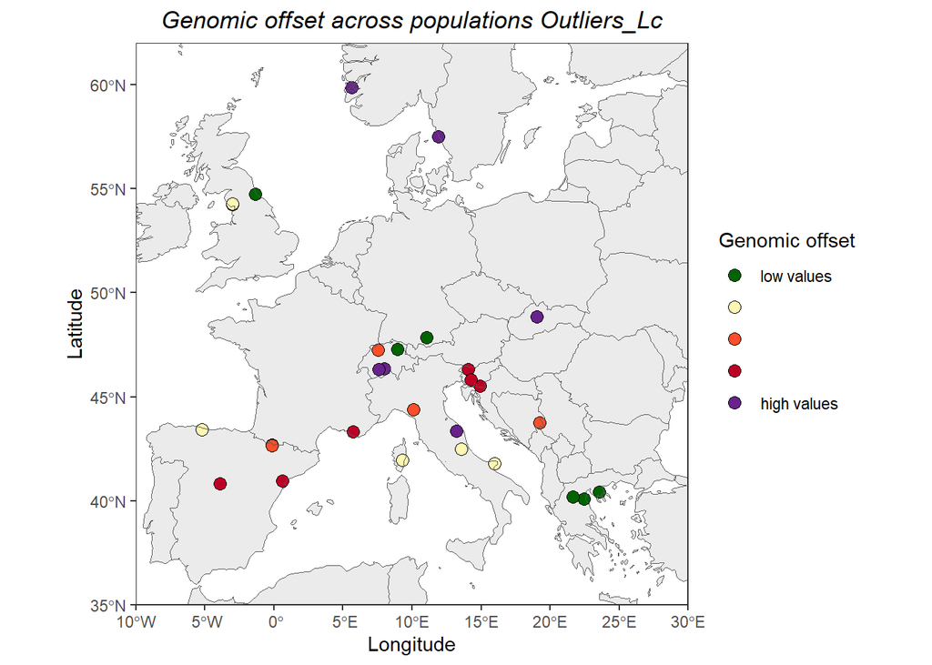

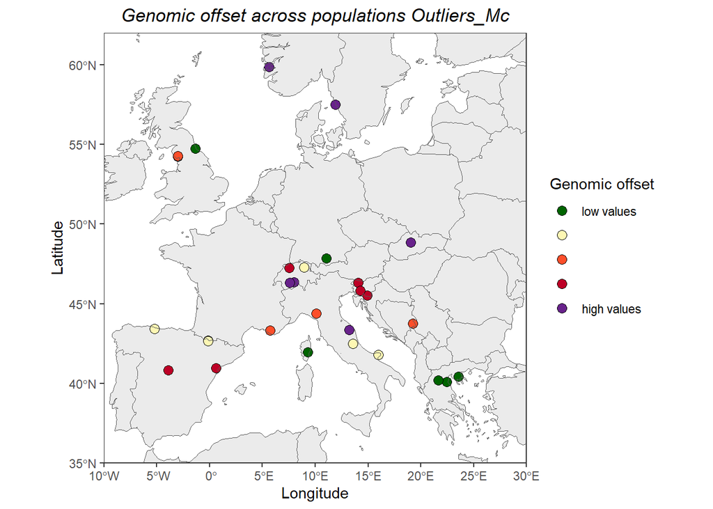

```r
list_GO <- c("Genomic_offset_Taxus_Adapcon_Gentree_RDA","Genomic_offset_Taxus_Adapcon_Gentree_RDA_MC")

for(x in 1:length(list_GO)){
  GO_df <- get(list_GO[x])
  name <- c("Outliers_Lc","Outliers_Mc")

 #first, we need to add the coordinates
Genomic_offset_coord <- merge(GO_df,meta_data_pop[,c(2,4,5)],"Population")

#transform longitude and latitude to numeric variables
Genomic_offset_coord <- Genomic_offset_coord %>% mutate(Longitude=as.numeric(Longitude),Latitude=as.numeric(Latitude))


colors <- c( "darkgreen", "#FDF7B3","#FC4E2A","#BD0026","darkorchid4")
#background map
admin <- ne_countries(scale = "medium", returnclass = "sf")

plot <- ggplot(data = Genomic_offset_coord) +
  geom_sf(data = admin, fill = gray(0.92), size = 0) +
  geom_point(aes(x = Longitude, y = Latitude, fill = cut_number(Genomic_offset_coord[,2], n = 5)), shape = 21,size=3, color = "black") +
  scale_fill_manual(
    values = colors,
    labels = c("low values","","","","high values"),
    drop = FALSE,na.translate = FALSE)+  # Ensure all levels are shown in the legend
  geom_sf(data = admin, fill = NA, size = 0.1) +
  coord_sf(xlim = c(-10, 30), ylim = c(35, 62), expand = FALSE) +
  xlab("Longitude") + ylab("Latitude") +
  guides(fill = guide_legend(title = "Genomic offset")) +
  ggtitle(paste0("Genomic offset across populations ",name[x])) +
  theme_bw(base_size = 11) +
  theme(legend.position="right", panel.grid = element_blank(), strip.text = element_text(size=11),plot.title = element_text(hjust = 0.5,color = "Black",face="italic"))

print(plot)

#save
      pdf(paste0("C:/Users/tfrancisco/Documents/Thèse/Results/species/taxus/Genomic_offset/RDA/figures/Genomic_offset_across_populations_",name[x],".pdf"));print(plot);dev.off()
}
```

Finally, we can compare the GO values between the two outliers set to see if the thresholds have an impact on the GO values:

```r
Correlation_GO_outliers_set <- cor(Genomic_offset_Taxus_Adapcon_Gentree_RDA_MC$Genomic_offset,Genomic_offset_Taxus_Adapcon_Gentree_RDA$Genomic_offset)

Correlation_GO_outliers_set
```

```
## [1] 0.9949019
```

We can see that the Go predictions gave almost identical results for both outliers set.

We can ask ourself that maybe the values are similar but the rank of population is not, we will investigate that:

```r
#merge two dataset
GO_RDA_set <- merge(Genomic_offset_Taxus_Adapcon_Gentree_RDA_MC,Genomic_offset_Taxus_Adapcon_Gentree_RDA,"Population")
#df
GO_RDA_set_df<- data.frame(Population= GO_RDA_set$Population,GO_GF_LC=GO_RDA_set$Genomic_offset_LC,GO_GF_MC=GO_RDA_set$Genomic_offset_MC)
```

We can also see if the rank of population is similar between outliers set. Populations with a rank near 1 are the ones with the lowest GO values.

```r
#RDA_GO rank
GO_RDA_set$rank_RDA_LC <- rank(GO_RDA_set$Genomic_offset_LC)

#GF_GO rank
GO_RDA_set$rank_RDA_MC <- rank(GO_RDA_set$Genomic_offset_MC)
```

We can plot the rank of the populations based on their GO value using a scatterplot:

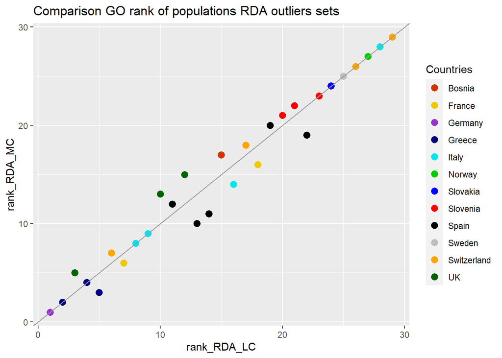

```r
GO_RDA_set_df_meta <- merge(GO_RDA_set,meta_data_pop[,c(1,2)],"Population")

GO_RDA_set_df_meta$Country <- as.factor(GO_RDA_set_df_meta$Country)

Scatterplot <- ggplot(GO_RDA_set_df_meta,aes(x=rank_RDA_LC,y=rank_RDA_MC)) +
  geom_point(aes(color=Country),size=3)+
  scale_colour_manual(name="Countries",
                      values = c("orangered3","gold2","darkorchid3","navyblue","turquoise2","green3","blue","red","black","gray","orange","darkgreen")) +
  geom_abline(intercept = 0, slope = 1, color="gray60")+
    ggtitle("Comparison GO rank of populations RDA outliers sets ")+
    theme_set(theme_bw())

plot(Scatterplot)
```